# Fake News Detection - Introduction

This project stands at the forefront of combating the escalating issue of misinformation in the media and on the internet, harnessing the power of data-driven insights and machine learning technologies. Central to the initiative is the LIAR dataset, an extensively curated repository of statements evaluated for their truthfulness across a spectrum from "true" to "pants on fire." This resource is instrumental in the endeavor to find patterns, indicators, and characteristics that signify fake news. Now, I embark on a mission to explore pivotal questions, such as the tendency of certain individuals or entities to disseminate misinformation, the role of specific contexts or platforms in amplifying fake news, and the prevalence of misinformation within discussions on various subjects.

**Objective:** I aim to answer questions such as:

- Are certain individuals or entities more inclined to propagate misinformation?
- Is misinformation more rampant in discussions about certain subjects, and does political affiliation influence the spread of false information?
- Is it possible to reliably detect whether a politically charged statement is true or false using models trained on similar statements.

**Methodology:** My approach combines exploratory data analysis (EDA) with advanced machine learning techniques. The EDA phase involves a deep dive into the LIAR dataset, enabling the formulation of hypotheses about the nature of fake news. Through this analysis, we can uncover the relationships between the veracity of statements and various factors like speaker identities, subject matters, and political leanings.

In the machine learning phase, I'll leverage models such as Support Vector Machines (SVM), K-Nearest Neighbors (KNN), Decision Trees, and XGBoost. These models are trained to classify statements based on their truthfulness, employing text data that has been preprocessed through TF-IDF vectorization and standard scaling to optimize model performance.

## Liar Training Dataset

We're first going to look at the training data of the dataset to form a hypothesis.

The overall question I'm trying to answer in this section is that are there certain indicators to detect fake news; such as certain people being more likely to spread false information, certain contexts where fake news is spread (like some podcasts, or some speakers, etc.), are some subjects more prone to having misinformation spread by a certain political party?

While exploring the data, I'll form more questions from that and building visualizations to show the data and explain it.

```python
import pandas as pd
import numpy as np
import seaborn as sns
import matplotlib.pyplot as plt
%matplotlib inline

from sklearn.model_selection import train_test_split
from sklearn.metrics import accuracy_score
from sklearn.metrics import classification_report
from sklearn.svm import SVC
import re
import string
```

# Exploratory Data Analysis

### While exploring the training data information, we'll want to identify any relationships that are found in the data.

### Questions to look into:

- Are there any relationships between how misinformation is spread?
- Do certain people have a pattern of spreading misinformation?
- Do political parties spread misinformation among different subjects?
- Can we quantify the label column as either true or false?

### Focusing the Data

In order to simplify the LIAR dataset for the machine learning models, I'll map the truth identifiers to a "Truth Index" that only has two values instead of six. True to half-true will map to a 1 or true, while barely-true to false will map to a 0 or false.

```python
# Open the csv test file and label the columns (Names from the README File)
liar = pd.read_csv("train.tsv", sep='\t', header=None,
                           names=["ID", "Label", "Statement", "Subject", "Speaker", "Speaker Job Title",
                                    "State Info", "Party Affiliation", "Barely True Count", "False Count",
                                  "Half True Count", "Mostly True Count", "Pants on Fire Count", "Context/Location"])

test = pd.read_csv("test.tsv", sep='\t', header=None, names=["ID", "Label", "Statement", "Subject", "Speaker", "Speaker Job Title",
                                                              "State Info", "Party Affiliation", "Barely True Count", "False Count",
                                                              "Half True Count", "Mostly True Count", "Pants on Fire Count", "Context/Location"])

hierarchy = {
    'true': 1,
    'mostly-true': 1,
    'half-true': 1,
    'barely-true': 0,
    'false': 0,
    'pants-fire': 0
}

liar["Truth Index"] = liar["Label"].map(hierarchy)
test["Truth Index"] = test["Label"].map(hierarchy)

liar
```

|  | ID | Label | Statement | Subject | Speaker | Speaker Job Title | State Info | Party Affiliation | Barely True Count | False Count | Half True Count | Mostly True Count | Pants on Fire Count | Context/Location | Truth Index |
| --- | --- | --- | --- | --- | --- | --- | --- | --- | --- | --- | --- | --- | --- | --- | --- |
| 0 | 2635.json | false | Says the Annies List political group supports ... | abortion | dwayne-bohac | State representative | Texas | republican | 0.0 | 1.0 | 0.0 | 0.0 | 0.0 | a mailer | 0 |
| 1 | 10540.json | half-true | When did the decline of coal start? It started... | energy,history,job-accomplishments | scott-surovell | State delegate | Virginia | democrat | 0.0 | 0.0 | 1.0 | 1.0 | 0.0 | a floor speech. | 1 |
| 2 | 324.json | mostly-true | Hillary Clinton agrees with John McCain "by vo... | foreign-policy | barack-obama | President | Illinois | democrat | 70.0 | 71.0 | 160.0 | 163.0 | 9.0 | Denver | 1 |
| 3 | 1123.json | false | Health care reform legislation is likely to ma... | health-care | blog-posting | NaN | NaN | none | 7.0 | 19.0 | 3.0 | 5.0 | 44.0 | a news release | 0 |
| 4 | 9028.json | half-true | The economic turnaround started at the end of ... | economy,jobs | charlie-crist | NaN | Florida | democrat | 15.0 | 9.0 | 20.0 | 19.0 | 2.0 | an interview on CNN | 1 |
| ... | ... | ... | ... | ... | ... | ... | ... | ... | ... | ... | ... | ... | ... | ... | ... |
| 10235 | 5473.json | mostly-true | There are a larger number of shark attacks in ... | animals,elections | aclu-florida | NaN | Florida | none | 0.0 | 1.0 | 1.0 | 1.0 | 0.0 | interview on "The Colbert Report" | 1 |
| 10236 | 3408.json | mostly-true | Democrats have now become the party of the [At... | elections | alan-powell | NaN | Georgia | republican | 0.0 | 0.0 | 0.0 | 1.0 | 0.0 | an interview | 1 |
| 10237 | 3959.json | half-true | Says an alternative to Social Security that op... | retirement,social-security | herman-cain | NaN | Georgia | republican | 4.0 | 11.0 | 5.0 | 3.0 | 3.0 | a Republican presidential debate | 1 |
| 10238 | 2253.json | false | On lifting the U.S. Cuban embargo and allowing... | florida,foreign-policy | jeff-greene | NaN | Florida | democrat | 3.0 | 1.0 | 3.0 | 0.0 | 0.0 | a televised debate on Miami's WPLG-10 against ... | 0 |
| 10239 | 1155.json | pants-fire | The Department of Veterans Affairs has a manua... | health-care,veterans | michael-steele | chairman of the Republican National Committee | Maryland | republican | 0.0 | 1.0 | 1.0 | 0.0 | 2.0 | a Fox News interview | 0 |

10240 rows × 15 columns

```python
# list all possible speakers
speakers = liar.groupby("Speaker").size().reset_index(name="count").sort_values(by="count", ascending=False)
speakers[speakers["count"] >= 75]
```

|  | Speaker | count |
| --- | --- | --- |
| 182 | barack-obama | 488 |
| 774 | donald-trump | 273 |
| 1112 | hillary-clinton | 239 |
| 1952 | mitt-romney | 176 |
| 2493 | scott-walker | 149 |
| 1416 | john-mccain | 148 |
| 2329 | rick-perry | 142 |
| 409 | chain-email | 142 |
| 1743 | marco-rubio | 117 |
| 2332 | rick-scott | 115 |
| 2649 | ted-cruz | 93 |
| 215 | bernie-s | 88 |
| 447 | chris-christie | 78 |
| 905 | facebook-posts | 78 |

# Are some speakers more likely to spread misinformation/fake news than others?

The first idea I'll explore is the relationship between a speaker and how often their statements turn out to be true or false.

- For looking at the relationships initially, I'll be focusing on three different people: former president Barack Obama, George Allen, and former president Donald Trump.
- The x-axis will be the different labels (true to pants-fire) and the y-axis will be the amount of statements that fall under each label

```python
# look at the specific speaker Barack Obama
# Does he seem to say what is normally one label or the other (are his statements mostly true or mostly false)?
liar_dataset_obama = liar.loc[liar["Speaker"] == "barack-obama"]
# liar_dataset_obama.sort_values(by="ID", ascending=False)
# Group by ID to focus on the labels of the articles. Not the subjects
lds_obama_grouped = liar_dataset_obama.groupby(["Label", "Truth Index"]).size().reset_index(name="count").sort_values(by='Truth Index', ascending=False)
lds_obama_grouped
```

|  | Label | Truth Index | count |
| --- | --- | --- | --- |
| 2 | half-true | 1 | 124 |
| 3 | mostly-true | 1 | 130 |
| 5 | true | 1 | 103 |
| 0 | barely-true | 0 | 56 |
| 1 | false | 0 | 67 |
| 4 | pants-fire | 0 | 8 |

# Creating the Visualisations

- By making these graphs, we will be able to study the relationship of individuals and how often they make truthful statements.

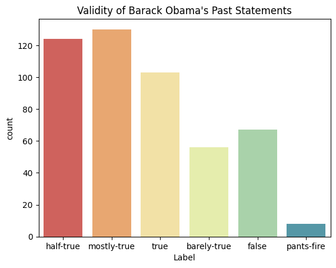

```python
# Create a visualization showing how Barack Obama's statements have been labeled
obama_barplot = sns.barplot(data=lds_obama_grouped, x="Label", y="count", palette="Spectral")
# sns.color_palette("Spectral", as_cmap=True)
obama_barplot.set_title("Validity of Barack Obama's Past Statements")
obama_barplot
```

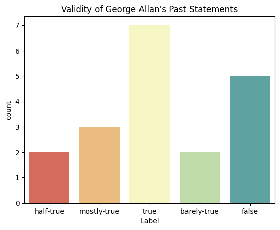

```python
# Create a visualization showing how George Allen's statements have been labeled
# speaker = liar_dataset.groupby(["Speaker", "Statement", "Speaker Job Title", "Truth Index", "Label", "Context/Location"]).size().reset_index(name="count").sort_values("count", ascending=False)
# speaker_statements = liar_dataset.groupby(["Speaker", "Statement",
#                                   "Truth Index", "Label"]).size().reset_index(name="count").sort_values("Speaker", ascending=True)
george_allen_dataset = liar.loc[liar["Speaker"] == "george-allen"]

george_allen_grouped = george_allen_dataset.groupby(["Label", "Truth Index"]).size().reset_index(name="count").sort_values(by="Truth Index", ascending=False)

george_allen_barplot = sns.barplot(data=george_allen_grouped, x="Label", y="count", palette="Spectral")
george_allen_barplot.set_title("Validity of George Allan's Past Statements")
george_allen_barplot
```

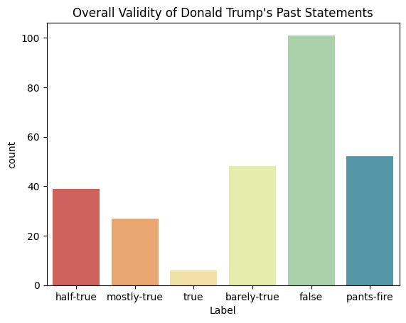

```python
donald_trump_dataset = liar.loc[(liar["Speaker"] == "donald-trump")]

donald_trump_grouped = donald_trump_dataset.groupby(["Label", "Truth Index"]).size().reset_index(name="count").sort_values(by="Truth Index", ascending=False)

donald_trump_barplot = sns.barplot(data=donald_trump_grouped, x="Label", y="count", palette="Spectral", hue="Label")
donald_trump_barplot.set_title("Overall Validity of Donald Trump's Past Statements")

donald_trump_barplot
```

```python
# Create a function to create visualizations for more speakers
def analyze_truth_by_individual(speaker, liar_dataset):
  dataset = liar_dataset.loc[(liar_dataset["Speaker"] == speaker)]

  dataset_grouped = dataset.groupby(["Label", "Truth Index"]).size().reset_index(name="count").sort_values(by="Truth Index", ascending=False)

  barplot = sns.barplot(data=dataset_grouped, x="Label", y="count", palette="Spectral", hue="Label")
  barplot.set_title("Overall Validity of " + speaker + "'s Past Statements")

  barplot
```

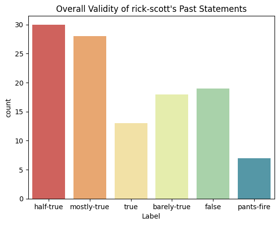

```python
analyze_truth_by_individual("rick-scott", liar)
# analyze_truth_by_individual("hillary-clinton", liar)
# analyze_truth_by_individual("marco-rubio", liar)
```

# Creating a honesty-dishonesty ratio and plotting of other individuals

Now that we have looked at the truthfulness of different individuals, we can make a scatterplot of individuals and where they lie in terms of a ratio of honesty and dishonesty to all statements.

- Those with a higher ratio would be considered as more honest than those who are not
- Some individuals tend to have more statements put out compared to others.It's crucial to consider not just the absolute quantity of truth versus lies spoken by an individual, but also the ratio of truth to lies when making our scatterplot.

By looking at the ratio of honesty and dishonesty to all statements, we can better analyze behaviors among people, and treat those with higher ratios as more trustworthy compared to others. For example, if person A has a higher number of truthful statements compared to person B, but person A tends to have a lower ratio of truths to lies compared to B, we can infer that A would have a higher propensity to lie than B.

The X axis will be the count of lies from an indivudal, and the Y axis will be the count of truthful statements from the individual.

# How do we interpret the scatterplot?

```python
# get the speakers and add number of statements, separated by truth index
speakers_stmts_by_truth_index = liar.groupby(["Speaker", "Truth Index"]).size().reset_index(name="count")
speakers_stmts_by_truth_index

speakers_stmt_count = liar.groupby('Speaker').size().reset_index(name='count')
speakers_stmt_count
```

|  | Speaker | count |
| --- | --- | --- |
| 0 | 18-percent-american-public | 2 |
| 1 | 60-plus-association | 2 |
| 2 | AARP | 1 |
| 3 | Arizona-Citizens-Defense-League | 2 |
| 4 | Ballesteros | 1 |
| ... | ... | ... |
| 2905 | yvette-mcgee-brown | 3 |
| 2906 | zack-space | 1 |
| 2907 | zell-miller | 3 |
| 2908 | zephyr-teachout | 1 |
| 2909 | zoe-lofgren | 1 |

2910 rows × 2 columns

```python
truthful_stmts = speakers_stmts_by_truth_index[speakers_stmts_by_truth_index["Truth Index"] == 1]
false_stmts = speakers_stmts_by_truth_index[speakers_stmts_by_truth_index["Truth Index"] == 0]

# Step 2: Calculate the counts for truthful and false statements
count_truthful = truthful_stmts.groupby("Speaker")["count"].sum().reset_index(name="True Count")
count_false = false_stmts.groupby("Speaker")["count"].sum().reset_index(name="False Count")

# Step 3: Merge the counts to get the ratio
# First, merge count_truthful and count_false on the "Speaker" column
merged_counts = pd.merge(count_truthful, count_false, on="Speaker", how="outer")

# clean the data - wherever there's a NaN value, it should be 0
merged_counts['True Count'] = merged_counts['True Count'].fillna(0)
merged_counts['False Count'] = merged_counts['False Count'].fillna(0)

# Calculate the ratio of truthful statements to false statements
merged_counts["ratio"] = merged_counts["True Count"] / (merged_counts["False Count"] + merged_counts['True Count'])

# # Now, add this ratio to speakers_stmt_count
# # Assuming speakers_stmt_count has a "Speaker" column that matches with the "Speaker" column in merged_counts
# speakers_stmt_count = pd.merge(speakers_stmt_count, merged_counts[["Speaker", "ratio"]], on="Speaker", how="left")

# # remove the speakers that have only a few statements
merged_counts.sort_values(by="ratio")
```

|  | Speaker | True Count | False Count | ratio |
| --- | --- | --- | --- | --- |
| 2909 | zack-space | 0.0 | 1.0 | 0.0 |
| 2317 | georgia-state-senators | 0.0 | 1.0 | 0.0 |
| 2316 | georgia-state-road-and-tollway-authority | 0.0 | 1.0 | 0.0 |
| 2315 | georgia-gun-owners | 0.0 | 1.0 | 0.0 |
| 2314 | georgia-department-transportation | 0.0 | 1.0 | 0.0 |
| ... | ... | ... | ... | ... |
| 1843 | texas-public-policy-foundation | 1.0 | 0.0 | 1.0 |
| 1842 | texas-petition | 1.0 | 0.0 | 1.0 |
| 1841 | texas-organizing-project | 1.0 | 0.0 | 1.0 |
| 1839 | texas-house-democratic-caucus | 1.0 | 0.0 | 1.0 |
| 1454 | pam-davidson | 1.0 | 0.0 | 1.0 |

2910 rows × 4 columns

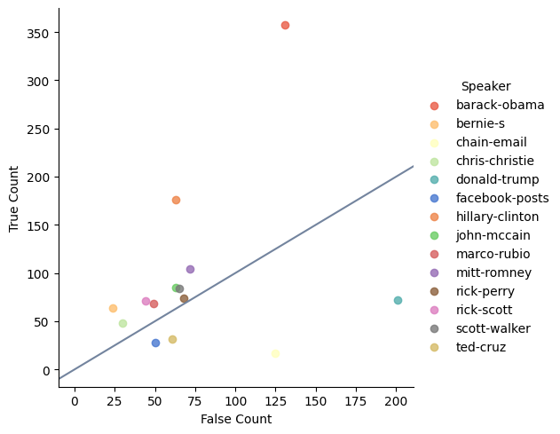

```python
# Create a merged palette with colors from spectral and muted color palettes
palette1 = sns.color_palette("Spectral", 5)
palette2 = sns.color_palette("muted", 10)
palette3 = sns.color_palette("pastel", 5)
merged_palette = palette1 + palette2 + palette3

palette = sns.color_palette(palette=merged_palette, n_colors=20)

# The x axis will be the ratio and the y axis will be the True Count. people who are more above on the line are the people who say more truths than lies
seaborn_plot = sns.lmplot(data=merged_counts[(merged_counts["True Count"] + merged_counts["False Count"]) >= 75],
           x="False Count", y="True Count", palette=merged_palette, hue="Speaker")

plt.axline((0, 0), slope=1, color='#73849e', linestyle='-')

# The ratios of true to false statements made by individuals with more than 50 statements
plt.show()
```

# Separating items with multiple subjects

Some of the subjects have multiple subjects that fall under multiple, already mentioned, subjects in the dataset. When we want to analyze how different subjects tend to have misinformation potentially spread by political parties, they must be separated.

- This will get only one subject per entry (e.g. a row with "alcohol, children, crime" as the subject will become 3 rows, so we can easily and more thoroughly group by subject)
- By not separating, an article that would be tied to the alcohol subject wouldn't be counted if its subject is "alcohol, children, and crime". It will be counted as its own subject.

```python
# This will separate each subject with multiple subjects into their own column (one subject per row)
# Note: some of the subjects seem to have multiple subjects related to it
# Open the csv test file and label the columns (Names from the README File)
liar_dataset_exploded = pd.read_csv("train.tsv", sep='\t', header=None,
                           names=["ID", "Label", "Statement", "Subject", "Speaker", "Speaker Job Title",
                                  "State Info", "Party Affiliation", "Barely True Count", "False Count",
                                  "Half True Count", "Mostly True Count", "Pants on Fire Count", "Context/Location"])

hierarchy = {
    'true': 1,
    'mostly-true': 1,
    'half-true': 1,
    'barely-true': 0,
    'false': 0,
    'pants-fire': 0
}

liar_dataset_exploded["Truth Index"] = liar_dataset_exploded["Label"].map(hierarchy)

# Make it so that the liar data set is exploded by subject - i.e. Each row will have one subject,
# The statements with multiple subjects will be repeated but with a different subjecty
liar_dataset_exploded["Subject"] = liar_dataset_exploded["Subject"].str.split(",")
liar_dataset_exploded = liar_dataset_exploded.explode("Subject")
liar_dataset_exploded['Subject'] = liar_dataset_exploded['Subject'].str.strip()
liar_dataset_exploded
```

|  | ID | Label | Statement | Subject | Speaker | Speaker Job Title | State Info | Party Affiliation | Barely True Count | False Count | Half True Count | Mostly True Count | Pants on Fire Count | Context/Location | Truth Index |
| --- | --- | --- | --- | --- | --- | --- | --- | --- | --- | --- | --- | --- | --- | --- | --- |
| 0 | 2635.json | false | Says the Annies List political group supports ... | abortion | dwayne-bohac | State representative | Texas | republican | 0.0 | 1.0 | 0.0 | 0.0 | 0.0 | a mailer | 0 |
| 1 | 10540.json | half-true | When did the decline of coal start? It started... | energy | scott-surovell | State delegate | Virginia | democrat | 0.0 | 0.0 | 1.0 | 1.0 | 0.0 | a floor speech. | 1 |
| 1 | 10540.json | half-true | When did the decline of coal start? It started... | history | scott-surovell | State delegate | Virginia | democrat | 0.0 | 0.0 | 1.0 | 1.0 | 0.0 | a floor speech. | 1 |
| 1 | 10540.json | half-true | When did the decline of coal start? It started... | job-accomplishments | scott-surovell | State delegate | Virginia | democrat | 0.0 | 0.0 | 1.0 | 1.0 | 0.0 | a floor speech. | 1 |
| 2 | 324.json | mostly-true | Hillary Clinton agrees with John McCain "by vo... | foreign-policy | barack-obama | President | Illinois | democrat | 70.0 | 71.0 | 160.0 | 163.0 | 9.0 | Denver | 1 |
| ... | ... | ... | ... | ... | ... | ... | ... | ... | ... | ... | ... | ... | ... | ... | ... |
| 10237 | 3959.json | half-true | Says an alternative to Social Security that op... | social-security | herman-cain | NaN | Georgia | republican | 4.0 | 11.0 | 5.0 | 3.0 | 3.0 | a Republican presidential debate | 1 |
| 10238 | 2253.json | false | On lifting the U.S. Cuban embargo and allowing... | florida | jeff-greene | NaN | Florida | democrat | 3.0 | 1.0 | 3.0 | 0.0 | 0.0 | a televised debate on Miami's WPLG-10 against ... | 0 |
| 10238 | 2253.json | false | On lifting the U.S. Cuban embargo and allowing... | foreign-policy | jeff-greene | NaN | Florida | democrat | 3.0 | 1.0 | 3.0 | 0.0 | 0.0 | a televised debate on Miami's WPLG-10 against ... | 0 |
| 10239 | 1155.json | pants-fire | The Department of Veterans Affairs has a manua... | health-care | michael-steele | chairman of the Republican National Committee | Maryland | republican | 0.0 | 1.0 | 1.0 | 0.0 | 2.0 | a Fox News interview | 0 |
| 10239 | 1155.json | pants-fire | The Department of Veterans Affairs has a manua... | veterans | michael-steele | chairman of the Republican National Committee | Maryland | republican | 0.0 | 1.0 | 1.0 | 0.0 | 2.0 | a Fox News interview | 0 |

22205 rows × 15 columns

## Studying the trends of statements of individuals based on their political party

Affiliations Objective: Looking into whether some parties have a trend of spreading more misinformation compared to others.

- There are more than 20 parties mentioned in the dataset. Some of these organizations have hundreds or thousands of statements made from individuals affiliated with those parties; however, there are some organizations that have only one or two statements. It'll be better to focus on just the top five parties with the most statements since they might have a larger influence compared to others.
- We can find the Political Parties with the most statements by "counting" the number of statements based on the "Political Affiliation" column and taking the top five. For the statements that do not fall in the top five, we will group them as "Other". There should be six different parties shown on the graph.

The reasoning to look at party affiliations is that if a certain affiliation has a trend of making mostly to completely false statements, we would know to treat the statements made by individuals of that party with more scrutiny when deciding to mark a statement as false.

# What we can learn from the graph below:

### The parties with the most statements made overall are Democrats and Republicans - The two prominent American political parties. Individuals with no party affiliation end up with the third highest count.

- Republicans tend to have a highest count of statements labeled as "pants-fire", "false", "barely true", or "half-true" compared to other parties' statements under the same label. Democrats seem to have a highest count of "mostly-true" statements compared to other political affiliations with the same label.
- Individuals with no affiliations seem to be distributed more evenly throughout the graph. However, the three labels with the highest number of unaffiliated speakers are "false", "half-true", and "mostly-true".
- Democrats' statements tend to be labeled as "mostly-true" and "half-true", or "true" across the graph, as compared to "barely-true", "false", and "pants on fire".

By looking at how statements' truthfulness compare between each party, we can identify where our model would need to focus on more when identifying fake news. If a certain party makes a higher number of false statements compared to other parties, then we could assume that there is a higher chance of that party making false statements in the future.

|  | ID | Label | Statement | Subject | Speaker | Speaker Job Title | State Info | Party Affiliation | Barely True Count | False Count | Half True Count | Mostly True Count | Pants on Fire Count | Context/Location | Truth Index |
| --- | --- | --- | --- | --- | --- | --- | --- | --- | --- | --- | --- | --- | --- | --- | --- |
| 0 | 2635.json | false | Says the Annies List political group supports ... | abortion | dwayne-bohac | State representative | Texas | republican | 0.0 | 1.0 | 0.0 | 0.0 | 0.0 | a mailer | 0 |
| 1 | 10540.json | half-true | When did the decline of coal start? It started... | energy,history,job-accomplishments | scott-surovell | State delegate | Virginia | democrat | 0.0 | 0.0 | 1.0 | 1.0 | 0.0 | a floor speech. | 1 |
| 2 | 324.json | mostly-true | Hillary Clinton agrees with John McCain "by vo... | foreign-policy | barack-obama | President | Illinois | democrat | 70.0 | 71.0 | 160.0 | 163.0 | 9.0 | Denver | 1 |
| 3 | 1123.json | false | Health care reform legislation is likely to ma... | health-care | blog-posting | NaN | NaN | none | 7.0 | 19.0 | 3.0 | 5.0 | 44.0 | a news release | 0 |
| 4 | 9028.json | half-true | The economic turnaround started at the end of ... | economy,jobs | charlie-crist | NaN | Florida | democrat | 15.0 | 9.0 | 20.0 | 19.0 | 2.0 | an interview on CNN | 1 |
| ... | ... | ... | ... | ... | ... | ... | ... | ... | ... | ... | ... | ... | ... | ... | ... |
| 10235 | 5473.json | mostly-true | There are a larger number of shark attacks in ... | animals,elections | aclu-florida | NaN | Florida | none | 0.0 | 1.0 | 1.0 | 1.0 | 0.0 | interview on "The Colbert Report" | 1 |
| 10236 | 3408.json | mostly-true | Democrats have now become the party of the [At... | elections | alan-powell | NaN | Georgia | republican | 0.0 | 0.0 | 0.0 | 1.0 | 0.0 | an interview | 1 |
| 10237 | 3959.json | half-true | Says an alternative to Social Security that op... | retirement,social-security | herman-cain | NaN | Georgia | republican | 4.0 | 11.0 | 5.0 | 3.0 | 3.0 | a Republican presidential debate | 1 |
| 10238 | 2253.json | false | On lifting the U.S. Cuban embargo and allowing... | florida,foreign-policy | jeff-greene | NaN | Florida | democrat | 3.0 | 1.0 | 3.0 | 0.0 | 0.0 | a televised debate on Miami's WPLG-10 against ... | 0 |
| 10239 | 1155.json | pants-fire | The Department of Veterans Affairs has a manua... | health-care,veterans | michael-steele | chairman of the Republican National Committee | Maryland | republican | 0.0 | 1.0 | 1.0 | 0.0 | 2.0 | a Fox News interview | 0 |

10238 rows × 15 columns

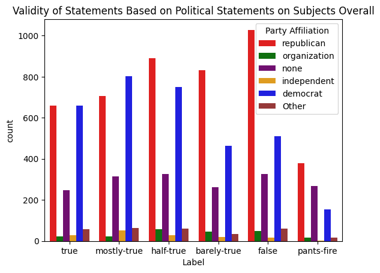

```python
# get the entries where there is a political affiliation associated with the individual
liar_subset = liar[
    (liar["Party Affiliation"].isnull() == False)]
liar_subset.groupby("Party Affiliation").size().reset_index(name="count")


# Step 1: Identify the top 4 party affiliations based on count
top_affiliations = liar_subset["Party Affiliation"].value_counts().index[:5]

# Step 2: Group the rest into "Other" and map every entry based on whether they fall into the top 5 affiliations
liar_subset['Party Affiliation'] = liar_subset['Party Affiliation'].apply(lambda x: x if (x in top_affiliations) else 'Other')

# filter by party, label, and truth index, and count the values that show up for each party affiliation
filtered_liar_dataset = liar_subset.groupby(['Party Affiliation',
                                             'Label', "Truth Index"]).size().reset_index(name='count').sort_values(by=['Party Affiliation',
                                                                                                                       "Truth Index"], ascending=False)
# filtered_liar_dataset
# How do certain subjects and their validity relate to one another
color_palette = {'republican': 'red', 'democrat': 'blue', 'none': 'purple', 'independent': 'orange', 'organization' : 'green', 'Other' : 'brown'}
desired_order = ['true', 'mostly-true', 'half-true', 'barely-true', 'false', 'pants-fire']

liar_barplot = sns.barplot(data=filtered_liar_dataset, x="Label", y="count", palette=color_palette, hue="Party Affiliation", errorbar=None, order=desired_order)
liar_barplot.set_title("Validity of Statements Based on Political Statements on Subjects Overall")
liar_barplot
liar_subset
```

# Among certain subjects, which party spreads the most misinformation?

## What we can learn from the graphs below:

### The parties with the most statements made overall are Democrats and Republicans - The two most prominent American political parties. Individuals with no party affiliation had the third highest count.

```python
# find individuals where the party affiliation is not null
liar_subset = liar_dataset_exploded [
    (liar_dataset_exploded["Party Affiliation"].isnull() == False)]
# energy_liar_subset

# find the top 5 affiliations in this dataset
top_affiliations = liar_subset["Party Affiliation"].value_counts().index[:5]   # this would take the affiliations among the parties
top_affiliations

# define the color palette in the top affiliations
color_palette = {'republican': 'red', 'democrat': 'blue', 'none': 'purple', 'independent': 'orange', 'organization' : 'green', 'Other' : 'brown'}
```

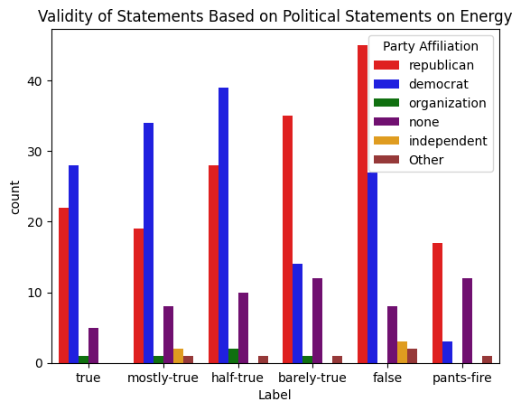

```python
energy_liar_subset = liar_subset[liar_subset["Subject"] == "energy"]
# # Step 2: Group the rest into "Other"
energy_liar_subset['Party Affiliation'] = energy_liar_subset['Party Affiliation'].apply(lambda x: x if (x in top_affiliations) else 'Other')

# # filter by subject, party, label, and truth index
filtered_liar_dataset = energy_liar_subset.groupby(['Subject', 'Party Affiliation', 'Label', "Truth Index"]).size().reset_index(name='count').sort_values(by='Truth Index', ascending=False)

# energy_liar_dataset = filtered_liar_dataset[filtered_liar_dataset["Subject"] == "energy"]     # filter for the entries where subject is energy
# # How do certain subjects and their validity relate to one another
desired_order = ['true', 'mostly-true', 'half-true', 'barely-true', 'false', 'pants-fire']

liar_barplot = sns.barplot(data=filtered_liar_dataset, x="Label", y="count", palette=color_palette, hue="Party Affiliation", errorbar=None, order=desired_order)
liar_barplot.set_title("Validity of Statements Based on Political Statements on Energy")
liar_barplot
```

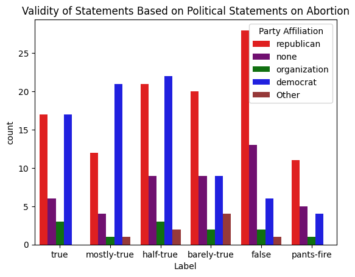

```python
abortion_liar_subset = liar_dataset_exploded[liar_dataset_exploded["Subject"] == "abortion"]     # filter for the entries where subject is abortion

# Step 2: Group the rest into "Other"
abortion_liar_subset['Party Affiliation'] = abortion_liar_subset['Party Affiliation'].apply(lambda x: x if (x in top_affiliations) else 'Other')

# filter by subject, party, label, and truth index
filtered_liar_dataset = abortion_liar_subset.groupby(['Subject', 'Party Affiliation', 'Label', "Truth Index"]).size().reset_index(name='count').sort_values(by='Truth Index', ascending=False)

# # # How do certain subjects and their validity relate to one another
desired_order = ['true', 'mostly-true', 'half-true', 'barely-true', 'false', 'pants-fire']
liar_barplot = sns.barplot(data=filtered_liar_dataset, x="Label", y="count", palette=color_palette, hue="Party Affiliation", errorbar=None, order=desired_order)
liar_barplot.set_title("Validity of Statements Based on Political Statements on Abortion")
liar_barplot
```

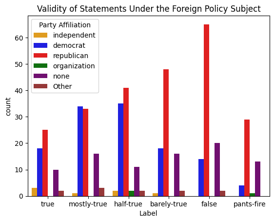

```python
# look at how the foreign policy subject statements match up between each party
foreign_policy_liar_subset = liar_dataset_exploded[liar_dataset_exploded["Subject"] == "foreign-policy"]     # filter for the entries where subject is energy

# Step 1: Identify the top 4 party affiliations based on count in this subset
# top_affiliations = alcohol_liar_subset["Party Affiliation"].value_counts().index[:5]

# # # Step 2: Group the rest into "Other"
foreign_policy_liar_subset['Party Affiliation'] = foreign_policy_liar_subset['Party Affiliation'].apply(lambda x: x if x in top_affiliations else 'Other')

# # # filter by subject, party, label, and truth index for the graph, and create a count index for counting the number of statements with each label
filtered_liar_dataset = foreign_policy_liar_subset.groupby(['Subject', 'Party Affiliation', 'Label', "Truth Index"]).size().reset_index(name='count').sort_values(by='Truth Index', ascending=False)

# # How do certain subjects and their validity relate to one another
desired_order = ['true', 'mostly-true', 'half-true', 'barely-true', 'false', 'pants-fire']
liar_barplot = sns.barplot(data=filtered_liar_dataset, x="Label", y="count", palette=color_palette, hue="Party Affiliation", errorbar=None, order=desired_order)
liar_barplot.set_title("Validity of Statements Under the Foreign Policy Subject")
liar_barplot
```

# Assuming statements could either be only true or only false, how often do political parties make false statements?

- We can assume that either statements can be only true or false.
- When grouping all the statements as "true" or "false" (true -> half-true = true and pants on fire -> barely true = false), we can look at how each of these parties line up in terms of trustworthiness of their statements.

|  | Party Affiliation | Truth Index | count |
| --- | --- | --- | --- |
| 1 | Other | 1 | 184 |
| 3 | democrat | 1 | 2209 |
| 5 | independent | 1 | 107 |
| 7 | none | 1 | 888 |
| 9 | organization | 1 | 107 |
| 11 | republican | 1 | 2257 |
| 0 | Other | 0 | 113 |
| 2 | democrat | 0 | 1127 |
| 4 | independent | 0 | 40 |
| 6 | none | 0 | 856 |
| 8 | organization | 0 | 112 |
| 10 | republican | 0 | 2240 |

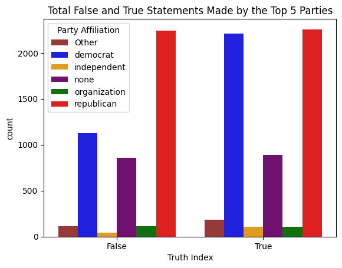

```python
true_false_liar_subset = liar

# find the columns in top_affiliations
true_false_liar_subset['Party Affiliation'] = true_false_liar_subset['Party Affiliation'].apply(lambda x: x if x in top_affiliations else 'Other')
true_false_liar_subset
true_false_liar_subset_grouped = liar.groupby(['Party Affiliation', "Truth Index"]).size().reset_index(name='count').sort_values(by='Truth Index', ascending=False)

total_per_each_party = liar.groupby(['Party Affiliation']).size().reset_index(name='count').sort_values(by='Party Affiliation', ascending=False)



# # How do certain subjects and their validity relate to one another
liar_barplot = sns.barplot(data=true_false_liar_subset_grouped, x="Truth Index", y="count", palette=color_palette, hue="Party Affiliation", errorbar=None)

# we will assume here that a statement can either be only false or true
liar_barplot.set_title("Total False and True Statements Made by the Top 5 Parties")
liar_barplot.set_xticklabels(['False', 'True'])
liar_barplot
true_false_liar_subset_grouped
# total_per_each_party
```

# Analysis of the results from above

There seems to be a higher count of Democrats and Republicans overall making statements; however, we can still see that there is a significant difference of false statements and true statements for Democrats, Independents, and "Others", showing that there is at least a slight higher chance that a statement made by one of these groups is true. Republicans and unaffiliated people, on the other hand, seem to have a trend of having a roughly almost equal number of false and true statements in the past. The only affiliation with more false statements than true statements made overall were organizations.

# Can we look at words that are used more often in a certain subject compared to others?

- Can we build a Table or a scatterplot or Pie Chart for showing what words are used in different subjects we looked at?
- TF IDF on certain words being used? and where they might fall in validity
- How often do certain individuals appear in telling the truth among others? make clusters to find out on a scatterplot

# Machine Learning Analysis

### When it comes to picking the best features to train the models on, ideally we'll want the features that are filled in the most.

```python
liar.info()
```

```
<class 'pandas.core.frame.DataFrame'>
RangeIndex: 10240 entries, 0 to 10239
Data columns (total 15 columns):
 #   Column               Non-Null Count  Dtype
---  ------               --------------  -----
 0   ID                   10240 non-null  object
 1   Label                10240 non-null  object
 2   Statement            10240 non-null  object
 3   Subject              10238 non-null  object
 4   Speaker              10238 non-null  object
 5   Speaker Job Title    7342 non-null   object
 6   State Info           8030 non-null   object
 7   Party Affiliation    10240 non-null  object
 8   Barely True Count    10238 non-null  float64
 9   False Count          10238 non-null  float64
 10  Half True Count      10238 non-null  float64
 11  Mostly True Count    10238 non-null  float64
 12  Pants on Fire Count  10238 non-null  float64
 13  Context/Location     10138 non-null  object
 14  Truth Index          10240 non-null  int64
dtypes: float64(5), int64(1), object(9)
memory usage: 1.2+ MB
```

### One final notable bit is that the dataset contains more true statements than false statements.

```python
liar['Truth Index'].value_counts()
```

```
Truth Index
1    5752
0    4488
Name: count, dtype: int64
```

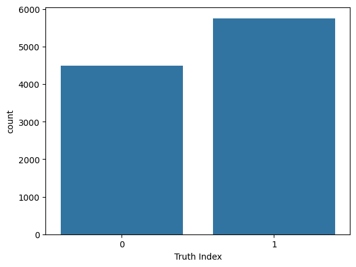

```python
sns.countplot(data=liar, x='Truth Index')
```

## Data Pre-Training

### Here I define the functions for the lemmatizer technique used in Homework 3 to truncate words into their root word (Ex: "doing" -> "do")

```python
import nltk

nltk.download('stopwords')
nltk.download('wordnet')
nltk.download('averaged_perceptron_tagger')
stopwords = nltk.corpus.stopwords.words('english')

posMapping = {
    "N":'n',
    "V":'v',
    "J":'a',
    "R":'r'
}

def remove_url(text):
    url_pattern = re.compile(r'https?://\S+|www\.\S+')
    res = re.sub(url_pattern, '', text)

    return res

def process(text, lemmatizer=nltk.stem.wordnet.WordNetLemmatizer()):
    text = remove_url(text)
    text = text.replace("'s", "")
    text = text.replace("'", "")
    for i in string.punctuation:
        text = text.replace(i, " ")

    tokenized = text.split()
    tags = nltk.pos_tag(tokenized)
    res = []
    for i in tags:
        if i[1][0] in posMapping:
            res.append(lemmatizer.lemmatize(i[0].lower(), pos=posMapping[i[1][0]]))
        else:
            res.append(lemmatizer.lemmatize(i[0].lower(), pos='n'))

    return res

def process_all(df, lemmatizer=nltk.stem.wordnet.WordNetLemmatizer()):
    df['Combined'] = df['Combined'].apply(lambda x: process(x, lemmatizer))
    return df
```

### First we must choose the features to train the model on. For this dataset, we'll use the Statement, Party Affiliation, and Subject features since they almost all filled in. If we included some other features such as Speaker we would end up with less entries to train the model on. We then use the functions defined above to lemmatize the words in the combined column.

### Next, we split the datasets into two sets of training and testing sets for each dataset we have.

```python
features = ["Statement", "Party Affiliation", "Subject"]

liar["Combined"] = liar[features].apply(lambda x: ' '.join(x.astype(str)), axis=1)
test["Combined"] = test[features].apply(lambda x: ' '.join(x.astype(str)), axis=1)

processed_liar = process_all(liar, lemmatizer=nltk.stem.wordnet.WordNetLemmatizer())
processed_test = process_all(test, lemmatizer=nltk.stem.wordnet.WordNetLemmatizer())

x_train = processed_liar["Combined"]
y_train = processed_liar["Truth Index"]

x_test = processed_test["Combined"]
y_test = processed_test["Truth Index"]
```

### Here, I apply TF-IDF vectorization to the training and test datasets from the liar set. This process not only uncovers the most relevant features of the data, but also allows the model to be trained by the vectorized data. I'll also use stopwords to ignore some irrelevant words.

```python
from sklearn.feature_extraction.text import TfidfVectorizer
from sklearn.preprocessing import StandardScaler

vectorization = TfidfVectorizer(min_df=2, tokenizer=(lambda x : x), stop_words=sorted(stopwords), lowercase=False)
xv_train = vectorization.fit_transform(x_train)
xv_test = vectorization.transform(x_test)
```

```python
scaler = StandardScaler(with_mean=False)
xv_train = scaler.fit_transform(xv_train)
xv_test = scaler.transform(xv_test)
```

### Printing the resulting features from the vectorization.

```python
feature_names = vectorization.get_feature_names_out()
print(feature_names)
```

```
['0' '00' '000' ... 'zombie' 'zone' '\x90']
```

# Various Model Training

### There are four main machine learning models I'll test:

1. Support Vector Machines (SVM) Classification
2. K-Nearest Neighbors (KNN) Classification
3. Decision Trees
4. XGBoost

Each of the models will use the TF-IDF vectorized training data as well as the training data for the output class to fit the data. Then, the model will continue on to train using the fitted data and the TF-IDF vectorized testing data. Finally, the model will be evaluated using the predicted classifications from the training and the testing data. The precision, recall and f1-scores will be printed, as well as the accuracy of the model. Furthermore, to supplement the precision and recall, a graph the confusion matrix for each model will be shown.

### Baseline comparison

The most basic way to compare our trained models is to come up with a baseline model that is simple and can serve as a benchmark for the success of the models. For this particular dataset, the baseline comparison would be a model that always says that the test statement is true. As mentioned earlier, there are far more true statements than false statements in the dataset. If this model was used on the training data, it would have an accuracy of about 56%.

In that instance, our models would have to be able to achieve an accuracy significantly greater than this baseline of 56% to be seen as a viable solution.

### SVM Classification

```python
#Training SVM model
svm_model = SVC(kernel='rbf', C=1.0, random_state=42,probability=True)
svm_model.fit(xv_train, y_train)

y_pred = svm_model.predict(xv_test)

#Model evaluation
accuracy_1 = accuracy_score(y_test, y_pred)
print("Accuracy:", accuracy_1)
print("Classification Report:")
print(classification_report(y_test, y_pred))
```

```
Accuracy: 0.601420678768745
Classification Report:
              precision    recall  f1-score   support

           0       0.57      0.38      0.45       553
           1       0.62      0.78      0.69       714

    accuracy                           0.60      1267
   macro avg       0.59      0.58      0.57      1267
weighted avg       0.59      0.60      0.58      1267
```

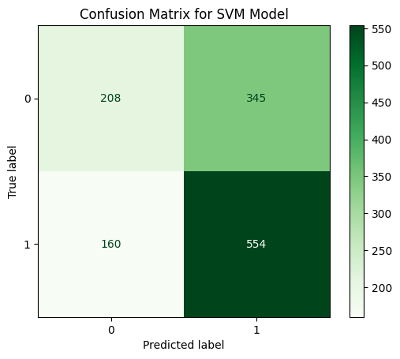

```python
from sklearn.metrics import confusion_matrix, ConfusionMatrixDisplay
cm = confusion_matrix(y_test, y_pred)

# Confusion Matrix
disp = ConfusionMatrixDisplay(confusion_matrix=cm)
disp.plot(cmap='Greens')
plt.title('Confusion Matrix for SVM Model')
plt.show()
```

## KNN Classification

```python
from sklearn.neighbors import KNeighborsClassifier
# Train KNN classifier
k = 5  # number of neighbors
knn_classifier = KNeighborsClassifier(n_neighbors=k)
knn_classifier.fit(xv_train, y_train)
y_pred = knn_classifier.predict(xv_test)
#Model evaluation
accuracy_2 = accuracy_score(y_test, y_pred)
print("Accuracy:", accuracy_2)
print("Classification Report:")
# Additional evaluation metrics
print(classification_report(y_test, y_pred))
```

```
Accuracy: 0.5706393054459353
Classification Report:
              precision    recall  f1-score   support

           0       0.51      0.29      0.37       553
           1       0.59      0.79      0.67       714

    accuracy                           0.57      1267
   macro avg       0.55      0.54      0.52      1267
weighted avg       0.56      0.57      0.54      1267
```

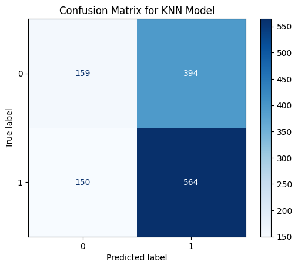

```python
cm = confusion_matrix(y_test, y_pred)

# Confusion Matrix
disp = ConfusionMatrixDisplay(confusion_matrix=cm)
disp.plot(cmap='Blues')
plt.title('Confusion Matrix for KNN Model')
plt.show()
```

## Decision Trees

```python
from sklearn.tree import DecisionTreeClassifier

DT = DecisionTreeClassifier()
DT.fit(xv_train, y_train)
y_pred = DT.predict(xv_test)
# Step 5: Model evaluation
accuracy_3 = accuracy_score(y_test, y_pred)
print("Accuracy:", accuracy_3)
print("Classification Report:")
print(classification_report(y_test, y_pred))
```

```
Accuracy: 0.5509076558800315
Classification Report:
              precision    recall  f1-score   support

           0       0.49      0.49      0.49       553
           1       0.60      0.60      0.60       714

    accuracy                           0.55      1267
   macro avg       0.54      0.54      0.54      1267
weighted avg       0.55      0.55      0.55      1267
```

[figure not shown]

```python
cm = confusion_matrix(y_test, y_pred)

# Confusion Matrix
disp = ConfusionMatrixDisplay(confusion_matrix=cm)
disp.plot(cmap='Reds')
plt.title('Confusion Matrix for Decistion tree Model')
plt.show()
```

## XGBoost

```
0.606156274664562
              precision    recall  f1-score   support

           0       0.56      0.47      0.51       553
           1       0.63      0.71      0.67       714

    accuracy                           0.61      1267
   macro avg       0.60      0.59      0.59      1267
weighted avg       0.60      0.61      0.60      1267
```

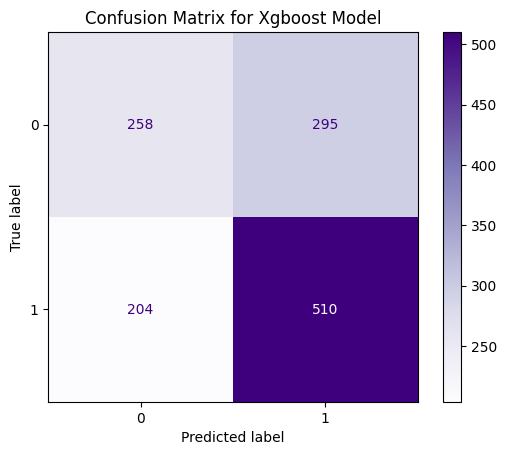

```python
import xgboost as xgb


xgb_model = xgb.XGBClassifier(objective="binary:logistic", random_state=42)
xgb_model.fit(xv_train, y_train)

y_pred = xgb_model.predict(xv_test)

accuracy_4 = accuracy_score(y_test, y_pred)
print(accuracy_4)
print(classification_report(y_test, y_pred))


cm = confusion_matrix(y_test, y_pred)

# Confusion Matrix
disp = ConfusionMatrixDisplay(confusion_matrix=cm)
disp.plot(cmap='Purples')
plt.title('Confusion Matrix for Xgboost Model')
plt.show()
```

### Plotting the decision tree where blue = true, and orange = false.

[figure not shown]

```python
from sklearn.tree import plot_tree
plt.figure(figsize=(20,10))
plot_tree(DT, filled=True, feature_names = feature_names, class_names=['False', 'True'], rounded=True, fontsize=12)
plt.show()
```

### Plotted below is the accuracy rating for each of the models.

[figure not shown]

```python
# Models accuracy scores
accuracies = {
    "SVM": accuracy_1,
    "KNN": accuracy_2,
    "Decision Tree": accuracy_3,
    "XGBoost": accuracy_4
}

colors = ["green", "orange", "red", "blue"]

# Plotting
plt.figure(figsize=(10, 6))
sns.set_style("whitegrid")
sns.barplot(x=list(accuracies.keys()), y=list(accuracies.values()), palette=colors, hue=list(accuracies.keys()))
plt.title('Comparing accuracy of ML models', fontsize=20)
plt.xticks(fontsize=12)
plt.yticks(fontsize=12)
plt.ylabel("Accuracy")
plt.xlabel("Classifiers")

plt.show()
```

### Plotted below is the ROC curve for the XGBoost model.

```
AUC-ROC: 0.6337902249507398
```

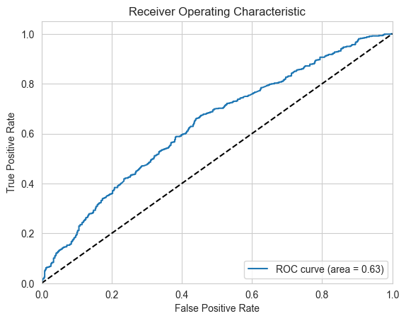

```python
from sklearn.metrics import  roc_auc_score, roc_curve, auc
y_proba = xgb_model.predict_proba(xv_test)[:, 1]  # Probability estimates for the positive class

# Calculate AUC
roc_auc = roc_auc_score(y_test, y_proba)
print(f'AUC-ROC: {roc_auc}')

# To plot the ROC curve
fpr, tpr, thresholds = roc_curve(y_test, y_proba)
plt.figure()
plt.plot(fpr, tpr, label=f'ROC curve (area = {roc_auc:.2f})')
plt.plot([0, 1], [0, 1], 'k--')  # Dashed diagonal
plt.xlim([0.0, 1.0])
plt.ylim([0.0, 1.05])
plt.xlabel('False Positive Rate')
plt.ylabel('True Positive Rate')
plt.title('Receiver Operating Characteristic')
plt.legend(loc='lower right')
plt.show()
```

# Interpretation of results

One last piece of insight, I curious as to what the runtime duration of each of the machine learning models is. Through multiple trials of each model, we found that XGBoost, Decision Trees and KNN classification run in a reasonable amount of time at 1.37s, 1.80s and 0.85s on average respectively. However, the SVM model takes a considerably longer amount of time to complete. On average, the model takes 51.2s to complete fitting, training, and evaluation, as the others did too. Although the SVM model performed better compared to some of the other models tested, the difference is accuracy isn't massive, unlike the difference in runtime.

# Reflection

### Returning to the initial objectives

- **Are certain individuals or entities more inclined to propagate misinformation?**

  At least when looking at the total counts of true/false statements for each subject matter, there isn't a significant difference in true or false counts across different subjects. The story does change when taking political affiliation into account. However, those findings aren't much different than those mentioned above.
- **Is it possible to reliably detect whether a politically charged statement is true or false using models trained on similar statements?**

  Unfortunately, from the results of testing four different models, I cannot say that it's possible. That is, when trained on the LIAR dataset. As mentioned in the interpretation of testing results, all of the models struggled to identify false statements, and instead were much better at identifying true ones. This goes back to the fact that the dataset contains more true statements than false ones. I believe the models would have benefitted greatly from a more balanced distribution of true/false statements.

### Conclusion

The ability to identify misinformation in the media and on the internet is becoming an increasingly crucial skill to have in this day and age. It's also rare to see people genuinely uphold the age old "Don't believe everything you see on the internet". Which is why the necessity for a tool such as this is so important. Although I couldn't create a reliable model for detecting misinformation, I absolutely believe that it can be accomplished. However, I don't feel that the LIAR dataset is good enough to produce that model. Some things can't reasonably be controlled, such as the possible biases in the dataset, since it would be virtually impossible to have no bias in such a dataset. Seeing past that, there are a multitude of problems with the dataset. Many entries have missing columns, so much so that some features are not usable in the training process. The six true/false classifiers are unnecessary--though I understand the benefit of more scrutiny in individual statements. However, the issue of having more truthful statements than false statements is likely the biggest shortcoming. All these factors lead me to believe that the LIAR dataset wouldn't produce a reliable model regardless of how many optimizations and hyperparameters are used.